# Actor-Partner Interactions

Back to schedule

# Introduction

- Between-Dyads Variable
  - Both members have the same score.
- Centering
  - Remove the mean from actor and partner variables.
  - Use one mean from the pairwise data set.
- Sequence of Testing
  - Test with actor and partner effects in the model.
  - Do not trim non-significant actor or partner effects.

## Hypothetical Example

**Outcome:** Satisfaction in Roommates  
**Predictor:** Agreeableness  
**Actor and Partner Main Effects:** Assumed to be positive

**Possible Effects:**

- Product Approach
  - Positive Coefficient: Being Agreeable makes you more satisfied but this effect is stronger the more Agreeable your roommate is (seems more likely).
  - Negative Coefficient: Being Agreeable makes you more satisfied but this effect is weaker the more Agreeable your roommate is.
- Discrepancy Score (Absolute Difference)
  - Positive Coefficient: The more dissimilar the two roommates are in Agreeableness, the more they are satisfied.
  - Negative Coefficient: The more similar the two roommates are in Agreeableness, the more they are satisfied (seems more likely).

# Riggs Example

## Load Data

Read in the pairwise dataset

```r
library(dyadr)
library(dplyr)
library(nlme)
library(ggplot2)

riggsp <- read.csv("riggsp.csv")
```

## Indistinguishable Dyads

First let’s again run the basic indistinguishable APIM.

```r
apimi <- gls(Sat_A ~ Avoid_A + Avoid_P,
             na.action = na.omit,
             correlation = corCompSymm (form=~1|Dyad),
             data = riggsp)

smallsummary(apimi)
```

```
## Correlation structure of class corCompSymm representing
##       Rho
## 0.6470868
##
## Residual standard error: 6.82339
##
##               Value Std.Error t-value p-value
## (Intercept) 49.5074    1.0337 47.8915  0.0000
## Avoid_A     -2.1249    0.3476 -6.1124  0.0000
## Avoid_P     -1.0902    0.3476 -3.1361  0.0019
```

```
##               2.5 %  97.5 %
## (Intercept) 47.4813 51.5335
## Avoid_A     -2.8062 -1.4435
## Avoid_P     -1.7715 -0.4088
```

Next, before we add the interaction, let’s grand-mean center the two variables. We will talk much more about centering tomorrow when we discuss moderation.

```r
riggsp <- riggsp %>%
  mutate(CAvoid_A = Avoid_A - mean(Avoid_A),
         CAvoid_P = Avoid_P - mean(Avoid_P))
```

### Product Approach

Now we will add the actor-partner interaction using the product approach.

```r
apimi_apint <- gls(Sat_A ~ CAvoid_A + CAvoid_P + CAvoid_A*CAvoid_P,
                   na.action = na.omit,
                   correlation = corCompSymm (form=~1|Dyad),
                   data = riggsp)

smallsummary(apimi_apint)
```

```
## Correlation structure of class corCompSymm representing
##       Rho
## 0.6483947
##
## Residual standard error: 6.836068
##
##                     Value Std.Error t-value p-value
## (Intercept)       44.8441    0.5010 89.5085  0.0000
## CAvoid_A          -2.1583    0.3534 -6.1080  0.0000
## CAvoid_P          -1.1236    0.3534 -3.1798  0.0016
## CAvoid_A:CAvoid_P -0.2839    0.5082 -0.5586  0.5768
```

```
##                     2.5 %  97.5 %
## (Intercept)       43.8622 45.8261
## CAvoid_A          -2.8508 -1.4657
## CAvoid_P          -1.8162 -0.4310
## CAvoid_A:CAvoid_P -1.2800  0.7122
```

There is no statistically significant actor-partner interaction, but the estimate is negative. We could interpret this tiny estimate as the negative actor effect of avoidance gets more negative if your partner is higher in avoidance.

### Descrepancy Approach

Next we’ll use the absolute discrepancy approach instead of the product approach. We have to add this variable to the dataset.

```r
riggsp <- riggsp %>%
  mutate(part_desc = abs(CAvoid_A - CAvoid_P))
```

Now we use this discrepancy in the model.

```r
apimi_desc <- gls(Sat_A ~ CAvoid_A + CAvoid_P + part_desc,
                   na.action = na.omit,
                   correlation = corCompSymm (form=~1|Dyad),
                   data = riggsp)

smallsummary(apimi_desc)
```

```
## Correlation structure of class corCompSymm representing
##       Rho
## 0.6458482
##
## Residual standard error: 6.811447
##
##               Value Std.Error t-value p-value
## (Intercept) 43.9011    0.8678 50.5899  0.0000
## CAvoid_A    -2.3720    0.3967 -5.9787  0.0000
## CAvoid_P    -1.3374    0.3967 -3.3708  0.0008
## part_desc    0.8034    0.6250  1.2855  0.1996
```

```
##               2.5 %  97.5 %
## (Intercept) 42.2002 45.6019
## CAvoid_A    -3.1496 -1.5944
## CAvoid_P    -2.1150 -0.5598
## part_desc   -0.4215  2.0283
```

The absolute discrepancy effect is not statistically significant, but the sign of the estimate is positive–this indicates that as the couple is more dissimilar in avoidance they are more happy.

## Distinguishable Dyads

Let’s first run the basic distinguishable dyads APIM. Here we use the two-intercept model.

```r
apimd <- gls(Sat_A ~ Genderstring + Genderstring:Avoid_A
             + Avoid_P:Genderstring - 1,
             na.action = na.omit,
             correlation = corCompSymm (form=~1|Dyad),
             weights = varIdent(form=~1|Genderstring),
             data = riggsp)

smallsummary(apimd)
```

```
## Correlation structure of class corCompSymm representing
##       Rho
## 0.6436512
##
## Variance function structure of class varIdent representing
##      Man    Woman
## 1.000000 1.022121
## Residual standard error: 6.756969
##
##                             Value Std.Error t-value p-value
## GenderstringMan           49.4068    1.1281 43.7956  0.0000
## GenderstringWoman         49.6339    1.1531 43.0447  0.0000
## GenderstringMan:Avoid_A   -1.7537    0.5075 -3.4560  0.0006
## GenderstringWoman:Avoid_A -2.4806    0.5062 -4.9008  0.0000
## GenderstringMan:Avoid_P   -1.3772    0.4952 -2.7812  0.0058
## GenderstringWoman:Avoid_P -0.7890    0.5187 -1.5212  0.1293
```

```
##                             2.5 %  97.5 %
## GenderstringMan           47.1958 51.6179
## GenderstringWoman         47.3739 51.8939
## GenderstringMan:Avoid_A   -2.7483 -0.7592
## GenderstringWoman:Avoid_A -3.4726 -1.4885
## GenderstringMan:Avoid_P   -2.3478 -0.4067
## GenderstringWoman:Avoid_P -1.8056  0.2276
```

All actor and partner effects are significant except for the men -> woman partner effect. We can use lincomb() to test if the actor and partner effects are different across gender.

```r
data.frame(Actor_effects = lincomb(apimd, 3, 4),
           Partner_effects = lincomb(apimd, 5, 6),
           row.names = c("Mean diff", "SE", "p-value"))
```

```
##           Actor_effects Partner_effects
## Mean diff     0.7268355      -0.5882618
## SE            0.7362712       0.7366442
## p-value       0.3235522       0.4245399
```

The actor and partner effects are not statistically different from each other. Note that although the men’s partner effect is sig and the women’s partner effects is not-sig, they are not significantly different from each other.

### Product Approach

Next we add the actor-partner interactions using the product approach.

```r
apimd_apint <- gls(Sat_A ~ Genderstring
                   + Genderstring:CAvoid_A + Genderstring:CAvoid_P
                   + Genderstring:CAvoid_A:CAvoid_P - 1,
                   na.action = na.omit,
                   correlation = corCompSymm (form=~1|Dyad),
                   weights = varIdent(form=~1|Genderstring),
                   data = riggsp)

smallsummary(apimd_apint)
```

```
## Correlation structure of class corCompSymm representing
##      Rho
## 0.657623
##
## Variance function structure of class varIdent representing
##      Man    Woman
## 1.000000 1.013844
## Residual standard error: 6.770519
##
##                                       Value Std.Error t-value p-value
## GenderstringMan                     44.8031    0.5481 81.7421  0.0000
## GenderstringWoman                   44.9597    0.5557 80.9079  0.0000
## GenderstringMan:CAvoid_A            -1.7219    0.5110 -3.3696  0.0009
## GenderstringWoman:CAvoid_A          -2.6165    0.5094 -5.1363  0.0000
## GenderstringMan:CAvoid_P            -1.3277    0.5025 -2.6425  0.0087
## GenderstringWoman:CAvoid_P          -0.8764    0.5181 -1.6916  0.0918
## GenderstringMan:CAvoid_A:CAvoid_P    0.3475    0.5548  0.6263  0.5316
## GenderstringWoman:CAvoid_A:CAvoid_P -0.9537    0.5625 -1.6954  0.0910
```

```
##                                       2.5 %  97.5 %
## GenderstringMan                     43.7288 45.8773
## GenderstringWoman                   43.8706 46.0489
## GenderstringMan:CAvoid_A            -2.7234 -0.7203
## GenderstringWoman:CAvoid_A          -3.6149 -1.6181
## GenderstringMan:CAvoid_P            -2.3125 -0.3429
## GenderstringWoman:CAvoid_P          -1.8918  0.1390
## GenderstringMan:CAvoid_A:CAvoid_P   -0.7400  1.4349
## GenderstringWoman:CAvoid_A:CAvoid_P -2.0561  0.1488
```

```r
L1 <- data.frame(Actor_effects = lincomb(apimd, 3, 4),
                 Partner_effects = lincomb(apimd, 5, 6),
                 APint = lincomb(apimd_apint, 7, 8),
                 row.names = c("Mean diff", "SE", "p-value"))

L1
```

```
##           Actor_effects Partner_effects       APint
## Mean diff     0.7268355      -0.5882618 1.301117875
## SE            0.7362712       0.7366442 0.462346775
## p-value       0.3235522       0.4245399 0.004890486
```

### Testing Simple Slopes

Let’s next explore what this interaction means by testing the simple slopes and graphing it. We will use a re-centering approach that allows us to see the effect of partner avoidance at high (+1 SD) and low (-1 SD) actor avoidance.

First we re-center actor avoidance. We want two new variables:

1. Where +1 SD now equals zero (HIGH)
2. Where -1 SD now equals zero (LOW)

```r
#That's right, we subtract for high and add for low!
riggsp <- riggsp %>%
  mutate(High_CAvoid_A = CAvoid_A - sd(CAvoid_A),
         Low_CAvoid_A = CAvoid_A + sd(CAvoid_A))
```

Then we use these in the models.

```r
apimd_high <- gls(Sat_A ~ Genderstring
                   + Genderstring:High_CAvoid_A + Genderstring:CAvoid_P
                   + Genderstring:High_CAvoid_A:CAvoid_P - 1,
                   na.action = na.omit,
                   correlation = corCompSymm (form=~1|Dyad),
                   weights = varIdent(form=~1|Genderstring),
                   data = riggsp)

apimd_low <- gls(Sat_A ~ Genderstring
                   + Genderstring:Low_CAvoid_A + Genderstring:CAvoid_P
                   + Genderstring:Low_CAvoid_A:CAvoid_P - 1,
                   na.action = na.omit,
                   correlation = corCompSymm (form=~1|Dyad),
                   weights = varIdent(form=~1|Genderstring),
                   data = riggsp)

summary(apimd_high)$tTable
```

```
##                                               Value Std.Error    t-value
## GenderstringMan                          42.9264037 0.7977925 53.8064767
## GenderstringWoman                        42.1080843 0.7586333 55.5051852
## GenderstringMan:High_CAvoid_A            -1.7218986 0.5110049 -3.3696322
## GenderstringWoman:High_CAvoid_A          -2.6164936 0.5094128 -5.1362938
## GenderstringMan:CAvoid_P                 -0.9490301 0.8448354 -1.1233313
## GenderstringWoman:CAvoid_P               -1.9157439 0.8411036 -2.2776551
## GenderstringMan:High_CAvoid_A:CAvoid_P    0.3474665 0.5548236  0.6262648
## GenderstringWoman:High_CAvoid_A:CAvoid_P -0.9536514 0.5625048 -1.6953657
##                                                p-value
## GenderstringMan                          8.812027e-157
## GenderstringWoman                        1.744099e-160
## GenderstringMan:High_CAvoid_A             8.504364e-04
## GenderstringWoman:High_CAvoid_A           5.034206e-07
## GenderstringMan:CAvoid_P                  2.621890e-01
## GenderstringWoman:CAvoid_P                2.344589e-02
## GenderstringMan:High_CAvoid_A:CAvoid_P    5.316143e-01
## GenderstringWoman:High_CAvoid_A:CAvoid_P  9.103676e-02
```

```r
summary(apimd_low)$tTable
```

```
##                                              Value Std.Error    t-value
## GenderstringMan                         46.6797292 0.7646638 61.0460801
## GenderstringWoman                       47.8114124 0.8115115 58.9164923
## GenderstringMan:Low_CAvoid_A            -1.7218986 0.5110049 -3.3696322
## GenderstringWoman:Low_CAvoid_A          -2.6164936 0.5094128 -5.1362938
## GenderstringMan:CAvoid_P                -1.7064237 0.7228286 -2.3607585
## GenderstringWoman:CAvoid_P               0.1629871 0.7622658  0.2138193
## GenderstringMan:Low_CAvoid_A:CAvoid_P    0.3474665 0.5548236  0.6262648
## GenderstringWoman:Low_CAvoid_A:CAvoid_P -0.9536514 0.5625048 -1.6953657
##                                               p-value
## GenderstringMan                         6.036219e-172
## GenderstringWoman                       1.197426e-167
## GenderstringMan:Low_CAvoid_A             8.504364e-04
## GenderstringWoman:Low_CAvoid_A           5.034206e-07
## GenderstringMan:CAvoid_P                 1.887285e-02
## GenderstringWoman:CAvoid_P               8.308323e-01
## GenderstringMan:Low_CAvoid_A:CAvoid_P    5.316143e-01
## GenderstringWoman:Low_CAvoid_A:CAvoid_P  9.103676e-02
```

All we care about is the effect of the partner’s avoidance for women when her avoidance is high…

```r
coef(summary(apimd_high))[c(2,6),]
```

```
##                                Value Std.Error   t-value       p-value
## GenderstringWoman          42.108084 0.7586333 55.505185 1.744099e-160
## GenderstringWoman:CAvoid_P -1.915744 0.8411036 -2.277655  2.344589e-02
```

…and when her avoidance is low.

```r
coef(summary(apimd_low))[c(2,6),]
```

```
##                                 Value Std.Error    t-value       p-value
## GenderstringWoman          47.8114124 0.8115115 58.9164923 1.197426e-167
## GenderstringWoman:CAvoid_P  0.1629871 0.7622658  0.2138193  8.308323e-01
```

### Graphing the Interaction

Finally, let’s graph the interaction. Let’s first make a dataset with only the women.

```r
womenOnly <- riggsp %>%
  filter(Gender_A == 1)
```

Now we will use the `graphMod()` function in `dyadr`. Type `?graphMod` to read about this function.

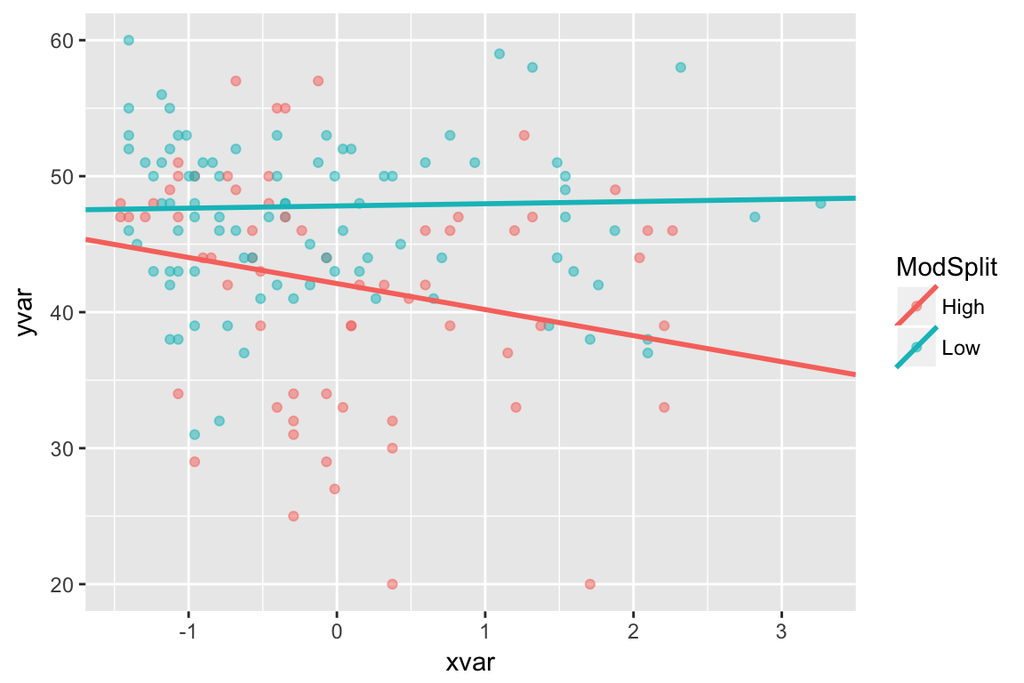

```r
plot <- graphMod(data = womenOnly,
                 x = womenOnly$CAvoid_P,
                 y = womenOnly$Sat_A,
                 mod = womenOnly$CAvoid_A,
                 highMod = apimd_high,
                 lowMod = apimd_low,
                 int = 2,
                 slp = 6)

plot
```

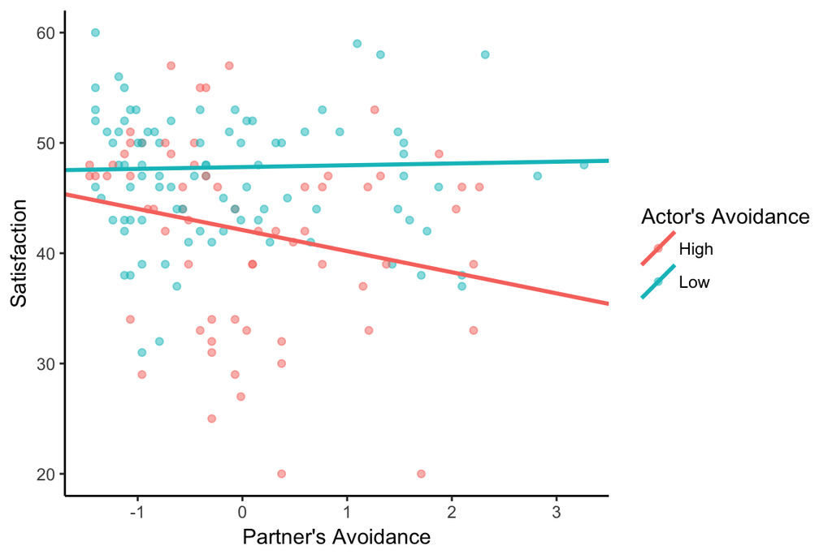

```r
plot +
  theme_classic() +
  ylab("Satisfaction") +
  xlab("Partner's Avoidance") +
  scale_color_manual(values = c("cadetblue", "salmon")) +
  scale_color_discrete(name = "Actor's Avoidance")
```

See a complete list of R colors [here](http://www.stat.columbia.edu/~tzheng/files/Rcolor.pdf).

Back to schedule